# Python workshop

# Operations with strings

- Concatenation: using operator + is possible to concatenate 2 or more strings:

#### Attention to the absence of space

```python
"Hello" + "World"  #  <- *Attention to the absence of space*
```

```
'HelloWorld'
```

- Repetition: using operator * is possible to repeat n times one string:

```python
"HelloWorld" * 3
```

```
'HelloWorldHelloWorldHelloWorld'
```

- Indexing: as mentioned before, is possible to recover one specific position of the string by index:

```python
"HelloWorld"[0]
```

```
'H'
```

- Slicing: it is possible to recover substring of strings with slicing notation:

```python
"HelloWorld"[2:4]  # Note that [2:4] will get the 3nd  and 4rd  position, not the 5th
```

```
'll'
```

- Size

```python
len("HelloWorld")
```

```
10
```

```python
type(len("HelloWorld")) # This is a int number
```

```
int
```

- Split: It is possible to use a substring (or character) to split a string:

```python
s = "Some things are immutable!"
```

```python
print(s.split())  # Default is space character
```

```
['Some', 'things', 'are', 'immutable!']
```

```python
print(s.split("a"))
```

```
['Some things ', 're immut', 'ble!']
```

```python
s2 = "You can split some strings, and you can decide how to do it!"
```

```python
print(s2.split(","))
```

```
['You can split some strings', ' and you can decide how to do it!']
```

```python
print(s2.split(",")[0])
```

```
You can split some strings
```

# Hands-on

- Print the 7th letter of the string "RafaelCuadrat"
- Split the names on string "Jorge,Rafael,Franziska,Daniel"
- Create a string using the 2 first and 2 last characters from the string "I love python"
- Add "ing" to the end of the string created.

# Escape sequences

- If you want to use some special characters with the literal meaning inside a string, you need to use backslash \ before.

  Ex: “The double quotation mark is \”” -> If you use only ” without \ it will close the string without show ” inside the string

  Ex2: “I like to use \” -> You need to use a backslash before a backslash to display \ inside a string
- Another scape sequences using backslash include:
  - New line: \newline
  - tabular space: \t <- very important dealing with tabular files

```python
# a wrong example
# print("This is quotes mark " in a string")
```

```python
print("This is quotes mark \" in a string")
```

```
This is quotes mark " in a string
```

```python
print("This is tabular t in a string")
```

```
This is tabular t in a string
```

```python
print("This is tabular \t in a string")
```

```
This is tabular 	 in a string
```

# Lists

- It is a versatile data type in python and can be written as comma-separated values (items) limited by [ ].
- Items in the list does not need to be of the same type!

```python
list1 = ['physics', 'chemistry', 1997, 2000]
list2 = [1, 2, 3, 4, 5 ]
list3 = ["a", "b", "c", "d"]
```

- Similar to string, index of list also starts with 0 and the list can be sliced, concatenated, etc.

```python
list1
```

```
['physics', 'chemistry', 1997, 2000]
```

```python
list1[-2]
```

```
1997
```

```python
list2[0:3]
```

```
[1, 2, 3]
```

```python
list3[2]
```

```
'c'
```

- Unlike strings, it is possible to update a list by changing an element:

```python
list1[2]
```

```
1997
```

```python
list1[2] = 2001 #replacing the item on position [2]  by the value 2001
```

```python
list1[2]
```

```
2001
```

```python
list1
```

```
['physics', 'chemistry', 2001, 2000]
```

```python
del list1[2] # deleting  item on position [2] from the list (2001)
```

```python
list1
```

```
['physics', 'chemistry', 2000]
```

# List operations

- The same as string for + (concatenation) and * (repetition) and most of operators. Ex: len(list)
- More examples:

```python
list1= ['physics', 'chemistry', 1997, 2000, 2004, 1999,2000]
```

```python
len(list1)
```

```
7
```

```python
2001 in list1
```

```
False
```

```python
2000 in list1
```

```
True
```

```python
list1.count(2000)
```

```
2
```

```python
list1=[ str(s) for s in list1 ]
```

```python
list1.sort()
```

```python
list1
```

```
['1997', '1999', '2000', '2000', '2004', 'chemistry', 'physics']
```

# Hans-on

- From the list provided:

1 - create a new list with the lengh of each item

2 - Calculate the number of occurrences of the string "google"

```python
list_hands_on = [11111, "python","perl","bash","R","google","microsoft","apple","google"]
```

# Tuple

- Tuple is very similar to list, but immutable.
- Instead [ ] it uses ( )

```python
tup1 = ('bla','ble','blu',1,30)
tup2 = (1,2,3,4,5,6)
tup3=(50)
```

# Dictionary

- In the dictionary, for every item there is a key and a value, separated by colon (:)
- The items are separated by comma (,)
- Keys are unique in a dictionary, but the values may be not.
- You can access the values by the key

```python
dict1 = {'Name': 'John', 'Age': 25, 'Class': 'First'}
```

```python
dict1['Name']
```

```
'John'
```

```python
dict1['Age']
```

```
25
```

# Comparison and logical operators in Python

## Logical:

```
 *and* -  both if both operators are true, the result is true
 *or*  - on of the operators is true, the result is true
 *not*  -  reverse the logical operator
```

## Comparison:

```
  ==  check if two values are equal. Ex: a == b.
  !=  check if two values are NOT equal.
  >   check if the left is greater than the right. Ex: a>b.
  <   check if the left is less than right
  >=  bigger or equal
  <=  smaller or equal
```

# Decision making

[figure not shown]

- For decision making it is possible to use just if for one single condition, if and elif for more than one condition and else for anything else (and every elif).

```python
var1=100
```

```python
if var1>90:
    print("Variable  is greater than 90")
```

```
Variable  is greater than 90
```

```python
if var1>90:
    print("Variable is greater than 90")
else:
    print("Variable can be equal or smaller than 90")
```

```
Variable is greater than 90
```

```python
var1=90
```

```python
if var1>90:
    print("Variable is greater than 90")
else:
    print("Variable can be equal or smaller than 90")
```

```
Variable can be equal or smaller than 90
```

```python
if var1>90:
    print("Variable is greater than 90")
elif var1<90:
    print("Variable is smaller than 90")
else:  #(could also be elif var1 == 90:)
    print("Variable is 90")
```

```
Variable is 90
```

# Identation

### Attention for the indentation in Python:

- No braces or reserved words to indicate blocks of code for class, functions or flow control. It is done by indentation.

[figure not shown]

# Loops

- Sometimes you need to repeat the same operations, so it is possible to use a loop, with a structure of repetition based in a decision or just a fixed number of times.

[figure not shown]

- *For* loop has the ability to iterate over the items of any sequence, such as a list or a string.

[figure not shown]

```python
for letter in 'Python bla':
    print('Current Letter :', letter)
```

```
Current Letter : P
Current Letter : y
Current Letter : t
Current Letter : h
Current Letter : o
Current Letter : n
Current Letter :
Current Letter : b
Current Letter : l
Current Letter : a
```

```python
fruits = ["apple", "mango", "banana"]
for fruit in fruits:
    print('Current fruit :', fruit)
```

```
Current fruit : apple
Current fruit : mango
Current fruit : banana
```

```python
fruits = ["apple", "mango", "banana"]
for fruit in fruits:
    for letter in fruit:
        print('Current fruit :', fruit, 'Current letter :', letter)
```

```
Current fruit : apple Current letter : a
Current fruit : apple Current letter : p
Current fruit : apple Current letter : p
Current fruit : apple Current letter : l
Current fruit : apple Current letter : e
Current fruit : mango Current letter : m
Current fruit : mango Current letter : a
Current fruit : mango Current letter : n
Current fruit : mango Current letter : g
Current fruit : mango Current letter : o
Current fruit : banana Current letter : b
Current fruit : banana Current letter : a
Current fruit : banana Current letter : n
Current fruit : banana Current letter : a
Current fruit : banana Current letter : n
Current fruit : banana Current letter : a
```

- *While* loop statement in Python programming language repeatedly executes a target statement as long as a given condition is true.

[figure not shown]

```python
count = 0
while (count < 9):
    print("The count is:", count)
    count = count+1
print("Bye!")
```

```
The count is: 0
The count is: 1
The count is: 2
The count is: 3
The count is: 4
The count is: 5
The count is: 6
The count is: 7
The count is: 8
Bye!
```

- The infinite loop: you need to take care when using while loops to not create an endless loop (unless you need one).

```
var == 1
while var == 1:
    print "Endless loop"
```

- To stop it you need to use CTRL+C

# Hands on:

- Create a list of words on the string "I'm learning python for bioinformatics"
- Create a loop and print all words from the list, but just if there is "n" in the word

# I/O in Python

- A program (or script) needs to deal with an input and to generate an output. In Python there are many ways to input data and we will see the most basic ones first.
- The input([prompt]) function reads one line from standard input and returns it as a string (removing the trailing newline).

```python
str_1 = input("Enter your input: ")
print("Received input is : ", str_1)
```

```
Enter your input: jorge
Received input is :  jorge
```

```python
# str_2 = input("Enter your input: ");
# print "Received input is : ", str_2
```

- Before read or write a file, you have to open it with the open() function.
- This function create a file object:

```python
afile = open("example.txt", "w+")
```

- The first argument is the file name, and the second is the “access mode”: It determines if the file will be only read, if can be write, append, etc. The default is r (read).
- In the example, w+ is for both writing and reading, overwriting the existing file if the file exists.
- Example of other modes are:

**‘w’** – Write mode which is used to edit and write new information to the file (any existing files with the same name will be erased when this mode is activated)

**‘a’** – Appending mode, which is used to add new data to the end of the file; that is new information is automatically amended to the end

**‘r+’** – Special read and write mode, which is used to handle both actions when working with a file

```python
afile #afile is an object
```

```
<_io.TextIOWrapper name='example.txt' mode='w+' encoding='UTF-8'>
```

- Writing text on the new file

```python
afile.write( "Python is amazing.\nYeah its great!!\n")  # \n is new line
```

```
36
```

- Closing the file:

```python
afile.close()
```

- Open, read and close a file:

```python
fo = open("example.txt", "r+")
```

```python
str_1 = fo.read()
```

```python
print(str_1.endswith)
```

```
<built-in method endswith of str object at 0x7f414dfc4138>
```

```python
str_1.splitlines()[1]
```

```
'Yeah its great!!'
```

```python
fo = open("example.txt", "r+")
str_2 = fo.read();
print(str_2)
fo.close()
```

```
Python is amazing.
Yeah its great!!
```

```python
fo.close()
```

```python
### include fasta file reading and manupulations
```

# Functions

- A function is a block of organized, reusable code that is used to perform a single, related action. Functions provide better modularity for your application and a high degree of code reusing.
- As you already know, Python gives you many built-in functions like print(), etc. but you can also create your own functions. These functions are called user-defined functions.
- You can define functions to provide the required functionality.
- Function blocks begin with the keyword def followed by the function name and parentheses ( ):

```python
def a_new_function():
    print("A new function")
    return
```

```python
a_new_function()
```

```
A new function
```

- Any input parameters or arguments should be placed within these parentheses. You can also define parameters inside these parentheses.
- The first statement of a function can be an optional statement - the documentation string of the function or docstring.
- The code block within every function starts with a colon (:) and is indented.
- The statement return [expression] exits a function, optionally passing back an expression to the caller. A return statement with no arguments is the same as return None.

```python
def a_new_function(a_str):
    print(a_str)
    return
```

```python
a_new_function("another string")
```

```
another string
```

- It is possible to use arguments as keyword arguments. It allows you to skip arguments or place out of order because python will identify by the keyword

```python
# Function definition is here
def printinfo( name, age ):
    "This prints a passed info into this function"
    print("Name: ", name)
    print("Age ", age)
    return;
```

```python
# Now you can call printinfo function - no keyword, but same order
printinfo("miki",50)
```

```
Name:  miki
Age  50
```

```python
printinfo(50,"miki")
```

```
Name:  50
Age  miki
```

```python
# Now you can call printinfo function - using the keywords
printinfo(age=50,name="miki")
```

```
Name:  miki
Age  50
```

- How to get help:

```python
help(printinfo)
```

```
Help on function printinfo in module __main__:

printinfo(name, age)
    This prints a passed info into this function
```

- It is possible to use default arguments:

```python
def printinfo( name, age = 35 ): # default argument age is 35
    "This prints a passed info into this function"
    print("Name: ", name)
    print("Age ", age)
    return;
```

```python
printinfo( name="miki" ) # no age argument, it will be the default
```

```
Name:  miki
Age  35
```

- The statement return [expression] exits a function, optionally passing back an expression to the caller. A return statement with no arguments is the same as return None.

```python
def sum_( arg1, arg2 ):
   # Add both the parameters and return them."
    total = arg1 + arg2
    print("Inside the function : ", total)
    return total;
```

```python
sum_( 10, 20 )
```

```
Inside the function :  30
```

```
30
```

### Global vs. Local variables:

- Variables that are defined inside a function body have a local scope, and those defined outside have a global scope.

```python
total = 0 # Global variable.
```

```python
def sum_2( arg1, arg2 ):
    # Add both the parameters and return them."
    total = arg1 + arg2; # Local variable.
    print("Inside the function local total : ", total)
    return
```

```python
sum_2( 10, 20 );
print("Outside the function global total : ", total )
```

```
Inside the function local total :  30
Outside the function global total :  0
```

# Modules

- A module allows you to logically organize your Python code. Grouping related code into a module makes the code easier to understand and use.
- A module is a Python object with arbitrarily named attributes that you can bind and reference.
- Simply, a module is a file consisting of Python code. A module can define functions, classes and variables. A module can also include runnable code.
- The Python code for a module named aname normally resides in a file named aname.py. Here's an example of a simple module, support.py

```python
def print_func( name ):
    print("Hello : ", name)
    return
```

```python
# Creating a module on fly - just illustrative, never do it, use a text editor or IDE
```

```python
new_mod=open("support.py","w+")
new_mod.write("def print_func( name ):\n\tprint(\"Hello : \", name)\n\treturn")
new_mod.close()
```

### To use a module you need first to import:

```python
# Import module support
import support

# Now you can call defined function that module as follows
support.print_func("Zara")
```

```
Hello :  Zara
```

### You can also use an alias for the module:

```python
# Import module support with an alias “sup”
import support as sup
```

```python
sup.print_func("Zara")
```

```
Hello :  Zara
```

# Hands-on

- Write a Python function that takes a list of words and returns the length of the longest one.

# Questions ???

[figure not shown]

# Second Day workshop

- Numerical operations (Numpy)
- Dataframes (pandas)
- Plots (matplotlib and seaborn)

# Numerical operations with Numpy

- Numpy is the core library for scientific computing in Python. It provides a high-performance multidimensional array object, and tools for working with these arrays (including many numerical operations)
- We will not cover arrays in detail, but we will see how to use numpy to do numerical operations
- NumPy’s array class is called ndarray. It is also known by the alias array. Note that numpy.array is not the same as the Standard Python Library class array.array, which only handles one-dimensional arrays and offers less functionality.

```python
import numpy as np
```

```python
a = np.arange(15).reshape(3,5)
```

```python
a
```

```
array([[ 0,  1,  2,  3,  4],
       [ 5,  6,  7,  8,  9],
       [10, 11, 12, 13, 14]])
```

```python
a = np.array([2,3,4])
b = np.array([2.1,3.2,4.5])
```

# Operations with Numpy

```python
c=a+b
c
```

```
array([4.1, 6.2, 8.5])
```

```python
d=a-b
d
```

```
array([-0.1, -0.2, -0.5])
```

```python
d**2
```

```
array([0.01, 0.04, 0.25])
```

```python
a*b # Element wise product
```

```
array([ 4.2,  9.6, 18. ])
```

```python
a.dot(b) # Matrix product
```

```
31.8
```

```python
e=np.arange(12).reshape(3,4)
e
```

```
array([[ 0,  1,  2,  3],
       [ 4,  5,  6,  7],
       [ 8,  9, 10, 11]])
```

```python
e.sum(axis=0)
```

```
array([12, 15, 18, 21])
```

```python
e.sum(axis=1)
```

```
array([ 6, 22, 38])
```

```python
e.min(axis=0)
```

```
array([0, 1, 2, 3])
```

```python
e.min(axis=1)
```

```
array([0, 4, 8])
```

```python
e.max(axis=1)
```

```
array([ 3,  7, 11])
```

```python
e.cumsum(axis=1)
```

```
array([[ 0,  1,  3,  6],
       [ 4,  9, 15, 22],
       [ 8, 17, 27, 38]])
```

```python
e.T
```

```
array([[ 0,  4,  8],
       [ 1,  5,  9],
       [ 2,  6, 10],
       [ 3,  7, 11]])
```

```python
e[2,3]
```

```
11
```

```python
e[-1]
```

```
array([ 8,  9, 10, 11])
```

# Hands-on

- with the 2 provided arrays:

1 - reshape both to 3 rows and 4 columns

2 - Transpose both

3 - calculate the sum of the cumsum of both arrays

```python
anewarray=np.random.rand(4,3)
anotherarray=np.random.rand(4,3)
```

# Introduction to data frames with Pandas

### What is a Pandas data frame?

- It is a two-dimensional size-mutable, potentially heterogeneous tabular data structure with labeled axes (rows and columns).
- Arithmetic operations align on both row and column labels.

[figure not shown]

- In general, we import a tabular or CSV file to a pandas dataframe
- The are some options, for example, we can use different separator character, we can read a file with or without a header

```python
import pandas as pd


df=pd.read_csv("new_AVS.tsv")
```

```python
df.head()
```

|  | metagenome: reads_sampled: trimmed_length: min_quality: mean_quality: filter_dups: max_unknown: average_genome_size: total_bases: genome_equivalents: |
| --- | --- |
| 0 | CAM_SMPL_003398\t14100\t400\t-5\t-5\tFalse\t10... |
| 1 | CAM_SMPL_003374\t35265\t450\t-5\t-5\tFalse\t10... |
| 2 | CAM_SMPL_003389\t12694\t400\t-5\t-5\tFalse\t10... |
| 3 | CAM_SMPL_003418\t13981\t450\t-5\t-5\tFalse\t10... |
| 4 | CAM_SMPL_003391\t26779\t400\t-5\t-5\tFalse\t10... |

```python
#checking the first rows of dataframe - It shows 5 rows by default, but you can pass argument inside ()
df.head()
```

|  | metagenome: reads_sampled: trimmed_length: min_quality: mean_quality: filter_dups: max_unknown: average_genome_size: total_bases: genome_equivalents: |
| --- | --- |
| 0 | CAM_SMPL_003398\t14100\t400\t-5\t-5\tFalse\t10... |
| 1 | CAM_SMPL_003374\t35265\t450\t-5\t-5\tFalse\t10... |
| 2 | CAM_SMPL_003389\t12694\t400\t-5\t-5\tFalse\t10... |
| 3 | CAM_SMPL_003418\t13981\t450\t-5\t-5\tFalse\t10... |
| 4 | CAM_SMPL_003391\t26779\t400\t-5\t-5\tFalse\t10... |

```python
df.tail() # Last 5 rows
```

|  | metagenome: reads_sampled: trimmed_length: min_quality: mean_quality: filter_dups: max_unknown: average_genome_size: total_bases: genome_equivalents: |
| --- | --- |
| 58 | CAM_SMPL_003359\t46837\t450\t-5\t-5\tFalse\t10... |
| 59 | CAM_SMPL_003382\t31822\t400\t-5\t-5\tFalse\t10... |
| 60 | CAM_SMPL_003357\t55946\t450\t-5\t-5\tFalse\t10... |
| 61 | CAM_SMPL_003368\t15148\t450\t-5\t-5\tFalse\t10... |
| 62 | CAM_SMPL_003378\t67961\t450\t-5\t-5\tFalse\t10... |

- By default, function read_csv() would use "," as separator to read the table.
- We can change it for any carachter, for example tabular "\t":

```python
df=pd.read_csv("new_AVS.tsv",sep="\t")
```

```python
df.head()
```

|  | metagenome: | reads_sampled: | trimmed_length: | min_quality: | mean_quality: | filter_dups: | max_unknown: | average_genome_size: | total_bases: | genome_equivalents: |
| --- | --- | --- | --- | --- | --- | --- | --- | --- | --- | --- |
| 0 | CAM_SMPL_003398 | 14100 | 400 | -5 | -5 | False | 100 | 1.444173e+06 | 9390688 | 6.502469 |
| 1 | CAM_SMPL_003374 | 35265 | 450 | -5 | -5 | False | 100 | 1.195763e+06 | 27953336 | 23.376988 |
| 2 | CAM_SMPL_003389 | 12694 | 400 | -5 | -5 | False | 100 | 1.185496e+06 | 9484191 | 8.000187 |
| 3 | CAM_SMPL_003418 | 13981 | 450 | -5 | -5 | False | 100 | 1.720945e+06 | 11153362 | 6.480953 |
| 4 | CAM_SMPL_003391 | 26779 | 400 | -5 | -5 | False | 100 | 1.461729e+06 | 17524363 | 11.988789 |

- It's also possible to read excel tables using read_excel("file.xls")

```python
df_cog=pd.read_excel("CAMERA_COG_RPKG_sig.xlsx")
```

#### This table stores the normalized abundance of each COG (ortholog genes) on each sample

```python
df_cog.head(10)
```

|  | Unnamed: 0 | CAM_SMPL_003410 | CAM_SMPL_003375 | CAM_SMPL_003388 | CAM_SMPL_003380 | CAM_SMPL_003361 | CAM_SMPL_003395 | CAM_SMPL_003378 | CAM_SMPL_003365 | CAM_SMPL_003373 | ... | g3-mean | g1-sd | g2-sd | g3-sd | ANOVA F | ANOVA pvalue | pvalue adjusted | log2(FC)_g1/g2 | log2(FC)_g1/g3 | log2(FC)_g2/g3 |
| --- | --- | --- | --- | --- | --- | --- | --- | --- | --- | --- | --- | --- | --- | --- | --- | --- | --- | --- | --- | --- | --- |
| 0 | COG0006 - Xaa-Pro aminopeptidase [Amino acid t... | 1.545723 | 4.167033 | 1.534017 | 0.000000 | 1.724899 | 0.000000 | 2.217853 | 6.629477 | 0.000000 | ... | 0.838736 | 1.323263 | 1.241376 | 1.042022 | 21.810674 | 7.604322e-08 | 0.000291 | 0.450025 | 1.961559 | 1.511534 |
| 1 | COG0018 - Arginyl-tRNA synthetase [Translation... | 1.024882 | 3.036821 | 2.855767 | 4.149942 | 0.000000 | 0.000000 | 3.104112 | 3.991667 | 0.000000 | ... | 0.933072 | 1.318947 | 1.371911 | 1.309937 | 15.510043 | 3.718949e-06 | 0.014236 | 0.463642 | 1.779949 | 1.316308 |
| 2 | COG0020 - Undecaprenyl pyrophosphate synthase ... | 0.000000 | 3.220692 | 0.973403 | 0.000000 | 1.542692 | 0.000000 | 1.481556 | 2.195459 | 0.000000 | ... | 0.388321 | 0.790581 | 0.971956 | 0.640390 | 17.853436 | 8.246011e-07 | 0.003157 | 0.751614 | 2.277260 | 1.525646 |
| 3 | COG0021 - Transketolase [Carbohydrate transpor... | 0.659364 | 2.388176 | 1.485892 | 0.000000 | 0.000000 | 0.000000 | 4.185504 | 5.248721 | 1.673285 | ... | 0.714487 | 1.139996 | 1.044342 | 1.109277 | 29.397518 | 1.260633e-09 | 0.000005 | 0.738438 | 2.211978 | 1.473539 |
| 4 | COG0028 - Acetolactate synthase large subunit ... | 1.799150 | 6.434617 | 4.867390 | 0.000000 | 3.255559 | 0.000000 | 4.231023 | 9.012939 | 2.817330 | ... | 2.285751 | 2.220290 | 2.264018 | 2.401486 | 15.491232 | 3.765361e-06 | 0.014414 | 0.330109 | 1.428212 | 1.098103 |
| 5 | COG0035 - Uracil phosphoribosyltransferase [Nu... | 0.000000 | 0.745211 | 0.205852 | 0.000000 | 0.000000 | 0.000000 | 2.261908 | 0.623539 | 0.000000 | ... | 0.186456 | 0.538982 | 0.359889 | 0.359018 | 15.691544 | 3.300370e-06 | 0.012634 | 0.927917 | 2.299039 | 1.371122 |
| 6 | COG0040 - ATP phosphoribosyltransferase [Amino... | 0.637089 | 0.948030 | 1.106626 | 0.000000 | 0.000000 | 1.385314 | 1.789779 | 1.529666 | 0.000000 | ... | 0.196886 | 0.611950 | 0.536970 | 0.408410 | 25.869401 | 7.914384e-09 | 0.000030 | 0.855852 | 2.785937 | 1.930085 |
| 7 | COG0049 - Ribosomal protein S7 [Translation, r... | 0.000000 | 0.000000 | 0.875543 | 0.000000 | 0.000000 | 0.000000 | 1.927435 | 1.336095 | 0.000000 | ... | 0.242650 | 0.538830 | 0.441765 | 0.537685 | 14.139673 | 9.306025e-06 | 0.035623 | 0.757113 | 2.144314 | 1.387201 |
| 8 | COG0050 - Translation elongation factor EF-Tu,... | 6.583426 | 4.057610 | 4.395697 | 2.263685 | 4.002741 | 0.000000 | 4.193771 | 6.215216 | 0.000000 | ... | 2.142647 | 1.355634 | 1.279844 | 2.319426 | 14.538509 | 7.105056e-06 | 0.027198 | 0.142089 | 1.167283 | 1.025195 |
| 9 | COG0064 - Asp-tRNAAsn/Glu-tRNAGln amidotransfe... | 3.050589 | 3.351769 | 1.429165 | 1.218677 | 0.000000 | 0.000000 | 2.973363 | 3.349802 | 0.000000 | ... | 1.206369 | 1.109038 | 1.057338 | 1.454888 | 15.511164 | 3.716203e-06 | 0.014226 | 0.531574 | 1.452333 | 0.920759 |

10 rows × 76 columns

# Working with the provided files

### It was provided 2 files from metagenomics analysis:

```python
df=pd.read_csv("new_AVS.tsv",sep="\t")
```

## This file is a parsed output from MicrobeCensus software:

https://github.com/snayfach/MicrobeCensus

MicrobeCensus is a fast and easy to use pipeline for estimating the average genome size (AGS) of a microbial community from metagenomic data.

```python
df.head()
```

|  | metagenome: | reads_sampled: | trimmed_length: | min_quality: | mean_quality: | filter_dups: | max_unknown: | average_genome_size: | total_bases: | genome_equivalents: |
| --- | --- | --- | --- | --- | --- | --- | --- | --- | --- | --- |
| 0 | CAM_SMPL_003398 | 14100 | 400 | -5 | -5 | False | 100 | 1.444173e+06 | 9390688 | 6.502469 |
| 1 | CAM_SMPL_003374 | 35265 | 450 | -5 | -5 | False | 100 | 1.195763e+06 | 27953336 | 23.376988 |
| 2 | CAM_SMPL_003389 | 12694 | 400 | -5 | -5 | False | 100 | 1.185496e+06 | 9484191 | 8.000187 |
| 3 | CAM_SMPL_003418 | 13981 | 450 | -5 | -5 | False | 100 | 1.720945e+06 | 11153362 | 6.480953 |
| 4 | CAM_SMPL_003391 | 26779 | 400 | -5 | -5 | False | 100 | 1.461729e+06 | 17524363 | 11.988789 |

- The samples used on this study are from GOS - baltic sea.

### Checking the column names:

```python
df.columns
```

```
Index(['metagenome:', 'reads_sampled:', 'trimmed_length:', 'min_quality:',
       'mean_quality:', 'filter_dups:', 'max_unknown:', 'average_genome_size:',
       'total_bases:', 'genome_equivalents:'],
      dtype='object')
```

```python
l=list(df.columns)
```

```python
l
```

```
['metagenome:',
 'reads_sampled:',
 'trimmed_length:',
 'min_quality:',
 'mean_quality:',
 'filter_dups:',
 'max_unknown:',
 'average_genome_size:',
 'total_bases:',
 'genome_equivalents:']
```

### Subseting a dataframe:

### For us, its only important now 2 columns

```python
new_df=df[["metagenome:","average_genome_size:","genome_equivalents:"]]
```

```python
new_df.head()
```

|  | metagenome: | average_genome_size: | genome_equivalents: |
| --- | --- | --- | --- |
| 0 | CAM_SMPL_003398 | 1.444173e+06 | 6.502469 |
| 1 | CAM_SMPL_003374 | 1.195763e+06 | 23.376988 |
| 2 | CAM_SMPL_003389 | 1.185496e+06 | 8.000187 |
| 3 | CAM_SMPL_003418 | 1.720945e+06 | 6.480953 |
| 4 | CAM_SMPL_003391 | 1.461729e+06 | 11.988789 |

### Rename columns (all):

```python
new_df.columns=["Sample","AGS","GE"]
```

```python
new_df.head()
```

|  | Sample | AGS | GE |
| --- | --- | --- | --- |
| 0 | CAM_SMPL_003398 | 1.444173e+06 | 6.502469 |
| 1 | CAM_SMPL_003374 | 1.195763e+06 | 23.376988 |
| 2 | CAM_SMPL_003389 | 1.185496e+06 | 8.000187 |
| 3 | CAM_SMPL_003418 | 1.720945e+06 | 6.480953 |
| 4 | CAM_SMPL_003391 | 1.461729e+06 | 11.988789 |

### Rename specific columns:

```python
new_df.rename(columns= {"Sample":"sample"},inplace=False).head() #Needs inplace = True to really change it
```

|  | sample | AGS | GE |
| --- | --- | --- | --- |
| 0 | CAM_SMPL_003398 | 1.444173e+06 | 6.502469 |
| 1 | CAM_SMPL_003374 | 1.195763e+06 | 23.376988 |
| 2 | CAM_SMPL_003389 | 1.185496e+06 | 8.000187 |
| 3 | CAM_SMPL_003418 | 1.720945e+06 | 6.480953 |
| 4 | CAM_SMPL_003391 | 1.461729e+06 | 11.988789 |

### Working with index on dataframes:

- this will set index and display the new_df with new index, but no alterations to original dataframe:

```python
new_df.set_index("Sample").head() #Just show the dataframe with the index on "Sample",
                                  # no alterations to original df
```

| Sample | AGS | GE |
| --- | --- | --- |
| CAM_SMPL_003398 | 1.444173e+06 | 6.502469 |
| CAM_SMPL_003374 | 1.195763e+06 | 23.376988 |
| CAM_SMPL_003389 | 1.185496e+06 | 8.000187 |
| CAM_SMPL_003418 | 1.720945e+06 | 6.480953 |
| CAM_SMPL_003391 | 1.461729e+06 | 11.988789 |

```python
#Original still unchanged
new_df.head()
```

|  | Sample | AGS | GE |
| --- | --- | --- | --- |
| 0 | CAM_SMPL_003398 | 1.444173e+06 | 6.502469 |
| 1 | CAM_SMPL_003374 | 1.195763e+06 | 23.376988 |
| 2 | CAM_SMPL_003389 | 1.185496e+06 | 8.000187 |
| 3 | CAM_SMPL_003418 | 1.720945e+06 | 6.480953 |
| 4 | CAM_SMPL_003391 | 1.461729e+06 | 11.988789 |

```python
new_df.set_index("Sample",inplace=True) # inplace=True modifies the dataframe
```

```python
# Now its changed
new_df.head()
```

| Sample | AGS | GE |
| --- | --- | --- |
| CAM_SMPL_003398 | 1.444173e+06 | 6.502469 |
| CAM_SMPL_003374 | 1.195763e+06 | 23.376988 |
| CAM_SMPL_003389 | 1.185496e+06 | 8.000187 |
| CAM_SMPL_003418 | 1.720945e+06 | 6.480953 |
| CAM_SMPL_003391 | 1.461729e+06 | 11.988789 |

### General statistic on dataframe:

```python
new_df.describe()
```

|  | AGS | GE |
| --- | --- | --- |
| count | 6.300000e+01 | 63.000000 |
| mean | 1.397449e+06 | 20.054522 |
| std | 3.212700e+05 | 17.076021 |
| min | 7.909761e+05 | 1.777490 |
| 25% | 1.182685e+06 | 6.281441 |
| 50% | 1.412405e+06 | 16.458093 |
| 75% | 1.635010e+06 | 30.137062 |
| max | 2.235292e+06 | 94.008744 |

### Get the min value from GE:

```python
new_df["GE"].min()
```

```
1.77748993023
```

### Get the min value from all columns:

```python
new_df.min()
```

```
AGS    790976.120718
GE          1.777490
dtype: float64
```

```python
new_df.max()
```

```
AGS    2.235292e+06
GE     9.400874e+01
dtype: float64
```

```python
new_df.dtypes
```

```
AGS    float64
GE     float64
dtype: object
```

```python
type(new_df)
```

```
pandas.core.frame.DataFrame
```

### Transpose dataframe:

```python
new_df.T
```

| Sample | CAM_SMPL_003398 | CAM_SMPL_003374 | CAM_SMPL_003389 | CAM_SMPL_003418 | CAM_SMPL_003391 | CAM_SMPL_003416 | CAM_SMPL_003372 | CAM_SMPL_003356 | CAM_SMPL_003406 | CAM_SMPL_003384 | ... | CAM_SMPL_003400 | CAM_SMPL_003388 | CAM_SMPL_003394 | CAM_SMPL_003358 | CAM_SMPL_003407 | CAM_SMPL_003359 | CAM_SMPL_003382 | CAM_SMPL_003357 | CAM_SMPL_003368 | CAM_SMPL_003378 |
| --- | --- | --- | --- | --- | --- | --- | --- | --- | --- | --- | --- | --- | --- | --- | --- | --- | --- | --- | --- | --- | --- |
| AGS | 1.444173e+06 | 1.195763e+06 | 1.185496e+06 | 1.720945e+06 | 1.461729e+06 | 1.179874e+06 | 1.851302e+06 | 1.232673e+06 | 1.458303e+06 | 954633.423109 | ... | 1.709527e+06 | 1.537633e+06 | 1.268083e+06 | 1.295514e+06 | 2.152113e+06 | 1.142553e+06 | 1.278940e+06 | 1.419555e+06 | 1.026569e+06 | 1.109780e+06 |
| GE | 6.502469e+00 | 2.337699e+01 | 8.000187e+00 | 6.480953e+00 | 1.198879e+01 | 3.388096e+01 | 1.290436e+01 | 2.672666e+01 | 5.378497e+01 | 53.653646 | ... | 1.860793e+01 | 2.890871e+01 | 4.623167e+01 | 2.374381e+00 | 5.126890e+00 | 2.573314e+01 | 1.675219e+01 | 3.168172e+01 | 1.212080e+01 | 4.157462e+01 |

2 rows × 63 columns

```python
#some hands on here
```

### Sort by values in one column (in this case, GE):

```python
new_df.sort_values(by="GE").head()
```

| Sample | AGS | GE |
| --- | --- | --- |
| CAM_SMPL_003367 | 1.082166e+06 | 1.777490 |
| CAM_SMPL_003364 | 1.480442e+06 | 1.863965 |
| CAM_SMPL_003358 | 1.295514e+06 | 2.374381 |
| CAM_SMPL_003386 | 1.151237e+06 | 3.005024 |
| CAM_SMPL_003373 | 9.909482e+05 | 3.064752 |

### By default it will sort ascending values, but you can specify to be descending:

```python
new_df.sort_values(by="GE",ascending=False).head()
```

| Sample | AGS | GE |
| --- | --- | --- |
| CAM_SMPL_003393 | 8.948887e+05 | 94.008744 |
| CAM_SMPL_003406 | 1.458303e+06 | 53.784971 |
| CAM_SMPL_003384 | 9.546334e+05 | 53.653646 |
| CAM_SMPL_003390 | 8.312135e+05 | 48.673980 |
| CAM_SMPL_003394 | 1.268083e+06 | 46.231671 |

### Selecting one column as Pandas Series:

```python
new_df["AGS"].head()
```

```
Sample
CAM_SMPL_003398    1.444173e+06
CAM_SMPL_003374    1.195763e+06
CAM_SMPL_003389    1.185496e+06
CAM_SMPL_003418    1.720945e+06
CAM_SMPL_003391    1.461729e+06
Name: AGS, dtype: float64
```

### Selecting one column as new Pandas DataFrame:

```python
new_df[["AGS"]].head()
```

| Sample | AGS |
| --- | --- |
| CAM_SMPL_003398 | 1.444173e+06 |
| CAM_SMPL_003374 | 1.195763e+06 |
| CAM_SMPL_003389 | 1.185496e+06 |
| CAM_SMPL_003418 | 1.720945e+06 |
| CAM_SMPL_003391 | 1.461729e+06 |

### Slicing by rows (positional):

```python
new_df.iloc[0:3]
```

| Sample | AGS | GE |
| --- | --- | --- |
| CAM_SMPL_003398 | 1.444173e+06 | 6.502469 |
| CAM_SMPL_003374 | 1.195763e+06 | 23.376988 |
| CAM_SMPL_003389 | 1.185496e+06 | 8.000187 |

### Slicing by rows (by index name):

```python
new_df.loc["CAM_SMPL_003398":"CAM_SMPL_003418"]
```

| Sample | AGS | GE |
| --- | --- | --- |
| CAM_SMPL_003398 | 1.444173e+06 | 6.502469 |
| CAM_SMPL_003374 | 1.195763e+06 | 23.376988 |
| CAM_SMPL_003389 | 1.185496e+06 | 8.000187 |
| CAM_SMPL_003418 | 1.720945e+06 | 6.480953 |

### Conditional selection:

```python
new_df[(new_df["GE"]<40) & (new_df["AGS"]>1000000)][["AGS"]].head()
```

| Sample | AGS |
| --- | --- |
| CAM_SMPL_003398 | 1.444173e+06 |
| CAM_SMPL_003374 | 1.195763e+06 |
| CAM_SMPL_003389 | 1.185496e+06 |
| CAM_SMPL_003418 | 1.720945e+06 |
| CAM_SMPL_003391 | 1.461729e+06 |

```python
new_df[new_df["GE"]>40] # Select the rows where GE is bigger than 40
```

| Sample | AGS | GE |
| --- | --- | --- |
| CAM_SMPL_003406 | 1.458303e+06 | 53.784971 |
| CAM_SMPL_003384 | 9.546334e+05 | 53.653646 |
| CAM_SMPL_003393 | 8.948887e+05 | 94.008744 |
| CAM_SMPL_003381 | 9.109262e+05 | 46.050540 |
| CAM_SMPL_003390 | 8.312135e+05 | 48.673980 |
| CAM_SMPL_003394 | 1.268083e+06 | 46.231671 |
| CAM_SMPL_003378 | 1.109780e+06 | 41.574616 |

### Operations with the values:

```python
new_df.max()-new_df.min()
```

```
AGS    1.444315e+06
GE     9.223125e+01
dtype: float64
```

### Create a new column based on results of operations:

```python
new_df["GE - AGS"]=new_df["GE"]-new_df["AGS"]
```

```python
new_df.head()
```

| Sample | AGS | GE | GE - AGS |
| --- | --- | --- | --- |
| CAM_SMPL_003398 | 1.444173e+06 | 6.502469 | -1.444166e+06 |
| CAM_SMPL_003374 | 1.195763e+06 | 23.376988 | -1.195740e+06 |
| CAM_SMPL_003389 | 1.185496e+06 | 8.000187 | -1.185488e+06 |
| CAM_SMPL_003418 | 1.720945e+06 | 6.480953 | -1.720938e+06 |
| CAM_SMPL_003391 | 1.461729e+06 | 11.988789 | -1.461717e+06 |

### Delete a column:

```python
del new_df["GE - AGS"]
```

```python
new_df.head()
```

| Sample | AGS | GE |
| --- | --- | --- |
| CAM_SMPL_003398 | 1.444173e+06 | 6.502469 |
| CAM_SMPL_003374 | 1.195763e+06 | 23.376988 |
| CAM_SMPL_003389 | 1.185496e+06 | 8.000187 |
| CAM_SMPL_003418 | 1.720945e+06 | 6.480953 |
| CAM_SMPL_003391 | 1.461729e+06 | 11.988789 |

```python
new_df["AGS - GE"]=new_df["AGS"]-new_df["GE"]
```

#### More about Pandas in: http://pandas.pydata.org/

#### Cheat Sheet: http://pandas.pydata.org/Pandas_Cheat_Sheet.pdf

# Hands on:

- read a dataframe (any!! From internet, from your computer...)
- print the columns
- store the column names into a list
- print the max value from the last column
- print the max value from the last row

# Plots with matplotlib

- Matplotlib is a Python 2D plotting library which produces publication quality figures in a variety of hardcopy formats and interactive environments across platforms. Matplotlib can be used in Python scripts, the Python and IPython shells, the Jupyter notebook, web application servers, and four graphical user interface toolkits.

#### https://matplotlib.org/

```python
import matplotlib.pyplot as plt
```

- Seaborn is a Python visualization library based on matplotlib. It provides a high-level interface for drawing attractive statistical graphics.

#### https://seaborn.pydata.org/

```python
import seaborn as sns
```

### Starting with plots - the ugly and lazy way

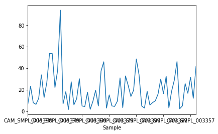

```python
#function plot direct from pandas dataframe
new_df["GE"].plot()
plt.show()
```

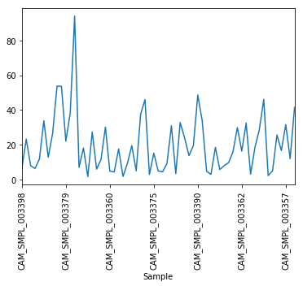

```python
#Rotate the name of samples

new_df["GE"].plot()


plt.xticks(rotation=90)

plt.show()
```

### This plot is useless, we dont have continuos data, we need a bar plot in this case

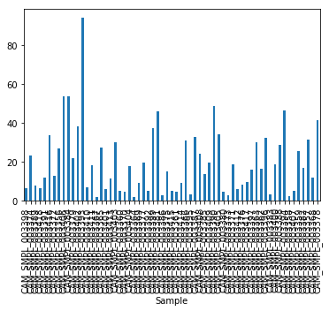

```python
new_df["GE"].plot(kind="bar")  # kind can be also pie, scatter, etc ...
plt.xticks(rotation=90)
plt.show()
```

### We need to control the size and style of figure, and also axis titles, etc

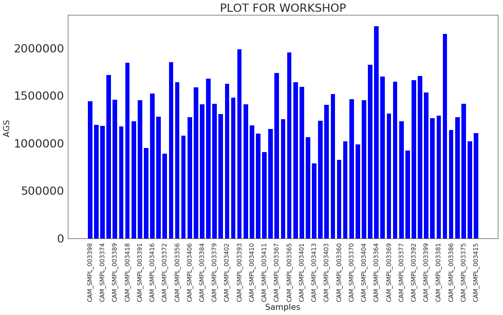

```python
sns.set_style("white")

#Define a figure and its size
plt.figure(figsize=(15,8))



#Bar plot

# range(len(new_df["AGS"])) -> define the number of bars to be plotted and the position on X axis
x=range(len(new_df["AGS"]))

# new_df["AGS"] -> values for axis Y
y=new_df["AGS"]

plt.bar(x,y,color="b")

#axis labels
plt.ylabel("AGS ",fontsize="16")
plt.xlabel("Samples",fontsize="16")

plt.title("PLOT FOR WORKSHOP",fontsize="22")
#xticks -> define the text to be ploted on axis X -> here we use index (the name of samples)


### error .... index values not matching the positions of xticks

plt.xticks(range(0,len(new_df.index),2), new_df.index,rotation="vertical",fontsize="12")
plt.yticks(fontsize="22")

## Save the figure in pdf

plt.savefig("my_first_plot.pdf", format = 'pdf', dpi = 300, bbox_inches = 'tight')

#Necessary to display the plot here
plt.show()
```

#### More about seaborn styles in: https://seaborn.pydata.org/generated/seaborn.set_style.html

### The values on Y are in bases, hard to read, so we can convert to Mb

```python
new_df["AGS (mb)"]=new_df["AGS"]/1000000
```

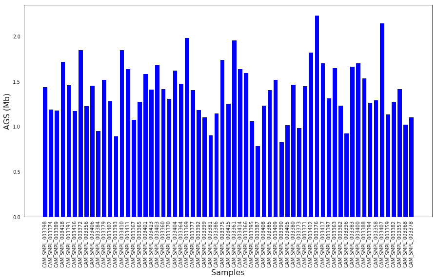

```python
#Seaborn style
sns.set_style("white")

#Define a figure and its size
plt.figure(figsize=(15,8))


x=range(len(new_df["AGS (mb)"]))

y=new_df["AGS (mb)"]


#Bar plot
plt.bar(x,y,color="b")

#axis labels
plt.ylabel("AGS (Mb)",fontsize="16")
plt.xlabel("Samples",fontsize="16")


plt.xticks(range(len(new_df.index)), new_df.index,rotation="vertical")

plt.show()
```

### Metadata from samples

```python
df2=pd.read_csv("metatable.csv", encoding = "latin")
```

```python
df2.head()
```

|  | SAMPLE_ACC | Sample Type | SAMPLE_VOLUME | VOLUME_UNIT | FILTER_MIN | FILTER_MAX | SAMPLE_DESCRIPTION | SAMPLE_NAME | COMMENTS | TAXON_ID | ... | MATERIAL_ID | sample depth - (m) | Ammonium - (umol/kg) | Silicate - (umol/kg) | Total phosphorus | salinity - (psu) | temperature - (C) | nitrite - (µmol/l) | phosphate - (umol/kg) | nitrate(NO3) - (umol/l) |
| --- | --- | --- | --- | --- | --- | --- | --- | --- | --- | --- | --- | --- | --- | --- | --- | --- | --- | --- | --- | --- | --- |
| 0 | CAM_SMPL_003356 | metagenome | 190 | L | 0.1 | 0.8 | NaN | GS682_0.1 | NaN | NaN | ... | 3785 | 24 | 0.263 | 7.079 | 0.395 | 8.00 | 9.47 | 0.033 | 0.208 | 0.212 |
| 1 | CAM_SMPL_003357 | metagenome | 190 | L | 0.8 | 3.0 | NaN | GS682_0.8 | NaN | NaN | ... | 3786 | 24 | 0.263 | 7.079 | 0.395 | 8.00 | 9.47 | 0.033 | 0.208 | 0.212 |
| 2 | CAM_SMPL_003358 | metagenome | 190 | L | 3.0 | 200.0 | NaN | GS682_3.0 | NaN | NaN | ... | 3787 | 24 | 0.263 | 7.079 | 0.395 | 8.00 | 9.47 | 0.033 | 0.208 | 0.212 |
| 3 | CAM_SMPL_003359 | metagenome | 180 | L | 0.1 | 0.8 | NaN | GS683_0.1 | NaN | NaN | ... | 3788 | 1 | 0.188 | 7.258 | 0.458 | 13.72 | 18.15 | NaN | 0.073 | 0.336 |
| 4 | CAM_SMPL_003360 | metagenome | 180 | L | 0.8 | 3.0 | NaN | GS683_0.8 | NaN | NaN | ... | 3789 | 1 | 0.188 | 7.258 | 0.458 | 13.72 | 18.15 | NaN | 0.073 | 0.336 |

5 rows × 41 columns

```python
new_df.head()
```

| Sample | AGS | GE | AGS - GE | AGS (mb) |
| --- | --- | --- | --- | --- |
| CAM_SMPL_003398 | 1.444173e+06 | 6.502469 | 1.444166e+06 | 1.444173 |
| CAM_SMPL_003374 | 1.195763e+06 | 23.376988 | 1.195740e+06 | 1.195763 |
| CAM_SMPL_003389 | 1.185496e+06 | 8.000187 | 1.185488e+06 | 1.185496 |
| CAM_SMPL_003418 | 1.720945e+06 | 6.480953 | 1.720938e+06 | 1.720945 |
| CAM_SMPL_003391 | 1.461729e+06 | 11.988789 | 1.461717e+06 | 1.461729 |

```python
new_df.reset_index(inplace=True)
```

```python
new_df.head()
```

|  | Sample | AGS | GE | AGS - GE | AGS (mb) |
| --- | --- | --- | --- | --- | --- |
| 0 | CAM_SMPL_003398 | 1.444173e+06 | 6.502469 | 1.444166e+06 | 1.444173 |
| 1 | CAM_SMPL_003374 | 1.195763e+06 | 23.376988 | 1.195740e+06 | 1.195763 |
| 2 | CAM_SMPL_003389 | 1.185496e+06 | 8.000187 | 1.185488e+06 | 1.185496 |
| 3 | CAM_SMPL_003418 | 1.720945e+06 | 6.480953 | 1.720938e+06 | 1.720945 |
| 4 | CAM_SMPL_003391 | 1.461729e+06 | 11.988789 | 1.461717e+06 | 1.461729 |

```python
# checking size of both dataframes, if they have same number of samples
```

```python
len(new_df)
```

```
63
```

```python
len(df2)
```

```
63
```

```python
#mergeing 2 df
merged=pd.merge(new_df,df2,left_on="Sample",right_on="SAMPLE_ACC")
```

```python
merged.head(15)
```

|  | Sample | AGS | GE | AGS - GE | AGS (mb) | SAMPLE_ACC | Sample Type | SAMPLE_VOLUME | VOLUME_UNIT | FILTER_MIN | ... | MATERIAL_ID | sample depth - (m) | Ammonium - (umol/kg) | Silicate - (umol/kg) | Total phosphorus | salinity - (psu) | temperature - (C) | nitrite - (µmol/l) | phosphate - (umol/kg) | nitrate(NO3) - (umol/l) |
| --- | --- | --- | --- | --- | --- | --- | --- | --- | --- | --- | --- | --- | --- | --- | --- | --- | --- | --- | --- | --- | --- |
| 0 | CAM_SMPL_003398 | 1.444173e+06 | 6.502469 | 1.444166e+06 | 1.444173 | CAM_SMPL_003398 | metagenome | 200 | L | 3.0 | ... | 3827 | 16 | 0.390 | 9.919 | 0.189 | 4.51 | 10.30 | NaN | 0.030 | 0.344 |
| 1 | CAM_SMPL_003374 | 1.195763e+06 | 23.376988 | 1.195740e+06 | 1.195763 | CAM_SMPL_003374 | metagenome | 200 | L | 0.1 | ... | 3803 | 30 | 0.196 | 5.747 | 0.461 | 32.40 | 13.54 | 0.047 | 0.124 | 1.305 |
| 2 | CAM_SMPL_003389 | 1.185496e+06 | 8.000187 | 1.185488e+06 | 1.185496 | CAM_SMPL_003389 | metagenome | 200 | L | 3.0 | ... | 3818 | 10 | 0.498 | 17.074 | 0.153 | 2.90 | 9.10 | 0.073 | 0.041 | 2.867 |
| 3 | CAM_SMPL_003418 | 1.720945e+06 | 6.480953 | 1.720938e+06 | 1.720945 | CAM_SMPL_003418 | metagenome | 200 | L | 3.0 | ... | 3847 | 19 | 0.472 | 4.685 | 0.345 | 33.05 | 17.47 | NaN | 0.027 | 0.495 |
| 4 | CAM_SMPL_003391 | 1.461729e+06 | 11.988789 | 1.461717e+06 | 1.461729 | CAM_SMPL_003391 | metagenome | 200 | L | 0.8 | ... | 3820 | 1 | 0.239 | 16.979 | 0.162 | 0.00 | 7.89 | NaN | 0.041 | 2.321 |
| 5 | CAM_SMPL_003416 | 1.179874e+06 | 33.880956 | 1.179840e+06 | 1.179874 | CAM_SMPL_003416 | metagenome | 200 | L | 0.1 | ... | 3845 | 19 | 0.472 | 4.685 | 0.345 | 33.05 | 17.47 | NaN | 0.027 | 0.495 |
| 6 | CAM_SMPL_003372 | 1.851302e+06 | 12.904355 | 1.851289e+06 | 1.851302 | CAM_SMPL_003372 | metagenome | 200 | L | 0.8 | ... | 3801 | 1 | 0.832 | 3.635 | 0.382 | 23.20 | 18.85 | NaN | 0.029 | 0.348 |
| 7 | CAM_SMPL_003356 | 1.232673e+06 | 26.726657 | 1.232646e+06 | 1.232673 | CAM_SMPL_003356 | metagenome | 190 | L | 0.1 | ... | 3785 | 24 | 0.263 | 7.079 | 0.395 | 8.00 | 9.47 | 0.033 | 0.208 | 0.212 |
| 8 | CAM_SMPL_003406 | 1.458303e+06 | 53.784971 | 1.458249e+06 | 1.458303 | CAM_SMPL_003406 | metagenome | 180 | L | 0.8 | ... | 3835 | 1 | 0.440 | 7.912 | 0.421 | 6.89 | 19.39 | NaN | 0.130 | 0.355 |
| 9 | CAM_SMPL_003384 | 9.546334e+05 | 53.653646 | 9.545798e+05 | 0.954633 | CAM_SMPL_003384 | metagenome | 200 | L | 0.1 | ... | 3813 | 1 | 0.177 | 22.688 | 0.188 | 2.90 | 10.80 | 0.073 | 0.061 | 2.571 |
| 10 | CAM_SMPL_003379 | 1.525316e+06 | 22.148538 | 1.525294e+06 | 1.525316 | CAM_SMPL_003379 | metagenome | 180 | L | 0.8 | ... | 3808 | 1 | 0.237 | 7.113 | 0.201 | 4.79 | 15.31 | NaN | 0.042 | 0.215 |
| 11 | CAM_SMPL_003402 | 1.283465e+06 | 38.315809 | 1.283427e+06 | 1.283465 | CAM_SMPL_003402 | metagenome | 200 | L | 0.1 | ... | 3831 | 74 | 1.372 | 27.640 | 2.267 | 9.90 | 5.32 | NaN | 1.796 | 0.645 |
| 12 | CAM_SMPL_003393 | 8.948887e+05 | 94.008744 | 8.947947e+05 | 0.894889 | CAM_SMPL_003393 | metagenome | 200 | L | 0.1 | ... | 3822 | 1 | 0.288 | 9.270 | 0.208 | 3.46 | 14.90 | NaN | 0.048 | 0.136 |
| 13 | CAM_SMPL_003410 | 1.853869e+06 | 7.070452 | 1.853862e+06 | 1.853869 | CAM_SMPL_003410 | metagenome | 200 | L | 3.0 | ... | 3839 | 1 | 0.757 | 7.458 | 0.424 | 7.52 | 17.56 | NaN | 0.110 | 0.210 |
| 14 | CAM_SMPL_003411 | 1.643691e+06 | 18.249304 | 1.643672e+06 | 1.643691 | CAM_SMPL_003411 | metagenome | 200 | L | 0.8 | ... | 3840 | 72 | 0.831 | 16.290 | 1.172 | 34.35 | 6.35 | NaN | 0.913 | 8.538 |

15 rows × 46 columns

```python
l1=list(merged.columns)
```

```python
#removing columns - (axis 1) -  where ALL the values are NaN (null, missing)
merged.dropna(how="all",axis=1,inplace=True)
```

```python
merged.head()
```

|  | Sample | AGS | GE | AGS - GE | AGS (mb) | SAMPLE_ACC | Sample Type | SAMPLE_VOLUME | VOLUME_UNIT | FILTER_MIN | ... | MATERIAL_ID | sample depth - (m) | Ammonium - (umol/kg) | Silicate - (umol/kg) | Total phosphorus | salinity - (psu) | temperature - (C) | nitrite - (µmol/l) | phosphate - (umol/kg) | nitrate(NO3) - (umol/l) |
| --- | --- | --- | --- | --- | --- | --- | --- | --- | --- | --- | --- | --- | --- | --- | --- | --- | --- | --- | --- | --- | --- |
| 0 | CAM_SMPL_003398 | 1.444173e+06 | 6.502469 | 1.444166e+06 | 1.444173 | CAM_SMPL_003398 | metagenome | 200 | L | 3.0 | ... | 3827 | 16 | 0.390 | 9.919 | 0.189 | 4.51 | 10.30 | NaN | 0.030 | 0.344 |
| 1 | CAM_SMPL_003374 | 1.195763e+06 | 23.376988 | 1.195740e+06 | 1.195763 | CAM_SMPL_003374 | metagenome | 200 | L | 0.1 | ... | 3803 | 30 | 0.196 | 5.747 | 0.461 | 32.40 | 13.54 | 0.047 | 0.124 | 1.305 |
| 2 | CAM_SMPL_003389 | 1.185496e+06 | 8.000187 | 1.185488e+06 | 1.185496 | CAM_SMPL_003389 | metagenome | 200 | L | 3.0 | ... | 3818 | 10 | 0.498 | 17.074 | 0.153 | 2.90 | 9.10 | 0.073 | 0.041 | 2.867 |
| 3 | CAM_SMPL_003418 | 1.720945e+06 | 6.480953 | 1.720938e+06 | 1.720945 | CAM_SMPL_003418 | metagenome | 200 | L | 3.0 | ... | 3847 | 19 | 0.472 | 4.685 | 0.345 | 33.05 | 17.47 | NaN | 0.027 | 0.495 |
| 4 | CAM_SMPL_003391 | 1.461729e+06 | 11.988789 | 1.461717e+06 | 1.461729 | CAM_SMPL_003391 | metagenome | 200 | L | 0.8 | ... | 3820 | 1 | 0.239 | 16.979 | 0.162 | 0.00 | 7.89 | NaN | 0.041 | 2.321 |

5 rows × 36 columns

```python
l2=list(merged.columns)
```

```python
[x for x in l1 if x not in l2]
```

```
['SAMPLE_DESCRIPTION',
 'COMMENTS',
 'TAXON_ID',
 'DESCRIPTION',
 'ALTITUDE',
 'SITE_DEPTH',
 'SITE_DESCRIPTION',
 'HOST_TAXON_ID',
 'HOST_DESCRIPTION',
 'HOST_ORGANISM']
```

### Sort values by filter size:

```python
merged=merged.sort_values("FILTER_MIN")
```

```python
merged.head(10)
```

|  | Sample | AGS | GE | AGS - GE | AGS (mb) | SAMPLE_ACC | Sample Type | SAMPLE_VOLUME | VOLUME_UNIT | FILTER_MIN | ... | MATERIAL_ID | sample depth - (m) | Ammonium - (umol/kg) | Silicate - (umol/kg) | Total phosphorus | salinity - (psu) | temperature - (C) | nitrite - (µmol/l) | phosphate - (umol/kg) | nitrate(NO3) - (umol/l) |
| --- | --- | --- | --- | --- | --- | --- | --- | --- | --- | --- | --- | --- | --- | --- | --- | --- | --- | --- | --- | --- | --- |
| 62 | CAM_SMPL_003378 | 1.109780e+06 | 41.574616 | 1.109738e+06 | 1.109780 | CAM_SMPL_003378 | metagenome | 180 | L | 0.1 | ... | 3807 | 1 | 0.237 | 7.113 | 0.201 | 4.79 | 15.31 | NaN | 0.042 | 0.215 |
| 51 | CAM_SMPL_003396 | 9.275912e+05 | 32.594154 | 9.275586e+05 | 0.927591 | CAM_SMPL_003396 | metagenome | 200 | L | 0.1 | ... | 3825 | 16 | 0.390 | 9.919 | 0.189 | 4.51 | 10.30 | NaN | 0.030 | 0.344 |
| 25 | CAM_SMPL_003377 | 1.412405e+06 | 19.604380 | 1.412385e+06 | 1.412405 | CAM_SMPL_003377 | metagenome | 200 | L | 0.1 | ... | 3806 | 72 | 0.831 | 16.290 | 1.172 | 34.35 | 6.35 | NaN | 0.913 | 8.538 |
| 61 | CAM_SMPL_003368 | 1.026569e+06 | 12.120798 | 1.026557e+06 | 1.026569 | CAM_SMPL_003368 | metagenome | 200 | L | 0.1 | ... | 3797 | 20 | 0.801 | 5.109 | 0.360 | 31.50 | 15.00 | 0.035 | 0.107 | 1.011 |
| 44 | CAM_SMPL_003371 | 1.456099e+06 | 18.592277 | 1.456081e+06 | 1.456099 | CAM_SMPL_003371 | metagenome | 200 | L | 0.1 | ... | 3800 | 1 | 0.832 | 3.635 | 0.382 | 23.20 | 18.85 | NaN | 0.029 | 0.348 |
| 50 | CAM_SMPL_003362 | 1.235364e+06 | 16.458093 | 1.235347e+06 | 1.235364 | CAM_SMPL_003362 | metagenome | 200 | L | 0.1 | ... | 3791 | 15 | 0.303 | 6.115 | 0.495 | 16.45 | 17.00 | NaN | 0.136 | 0.304 |
| 18 | CAM_SMPL_003413 | 1.414618e+06 | 11.659474 | 1.414606e+06 | 1.414618 | CAM_SMPL_003413 | metagenome | 200 | L | 0.1 | ... | 3842 | 1 | 0.328 | 2.895 | 0.335 | 32.16 | 17.43 | NaN | NaN | 0.365 |
| 16 | CAM_SMPL_003365 | 1.278115e+06 | 27.447482 | 1.278088e+06 | 1.278115 | CAM_SMPL_003365 | metagenome | 200 | L | 0.1 | ... | 3794 | 1 | 0.250 | 1.417 | 0.258 | 20.22 | 18.63 | NaN | NaN | 0.285 |
| 36 | CAM_SMPL_003387 | 7.909761e+05 | 32.882668 | 7.909432e+05 | 0.790976 | CAM_SMPL_003387 | metagenome | 200 | L | 0.1 | ... | 3816 | 10 | 0.498 | 17.074 | 0.153 | 2.90 | 9.10 | 0.073 | 0.041 | 2.867 |
| 27 | CAM_SMPL_003399 | 1.107213e+06 | 37.547570 | 1.107175e+06 | 1.107213 | CAM_SMPL_003399 | metagenome | 150 | L | 0.1 | ... | 3828 | 9 | 0.309 | 4.540 | 0.283 | 5.75 | 15.31 | NaN | 0.089 | 0.187 |

10 rows × 36 columns

```python
merged.reset_index(inplace=True,drop=True)
```

```python
merged.head(10)
```

|  | Sample | AGS | GE | AGS - GE | AGS (mb) | SAMPLE_ACC | Sample Type | SAMPLE_VOLUME | VOLUME_UNIT | FILTER_MIN | ... | MATERIAL_ID | sample depth - (m) | Ammonium - (umol/kg) | Silicate - (umol/kg) | Total phosphorus | salinity - (psu) | temperature - (C) | nitrite - (µmol/l) | phosphate - (umol/kg) | nitrate(NO3) - (umol/l) |
| --- | --- | --- | --- | --- | --- | --- | --- | --- | --- | --- | --- | --- | --- | --- | --- | --- | --- | --- | --- | --- | --- |
| 0 | CAM_SMPL_003378 | 1.109780e+06 | 41.574616 | 1.109738e+06 | 1.109780 | CAM_SMPL_003378 | metagenome | 180 | L | 0.1 | ... | 3807 | 1 | 0.237 | 7.113 | 0.201 | 4.79 | 15.31 | NaN | 0.042 | 0.215 |
| 1 | CAM_SMPL_003396 | 9.275912e+05 | 32.594154 | 9.275586e+05 | 0.927591 | CAM_SMPL_003396 | metagenome | 200 | L | 0.1 | ... | 3825 | 16 | 0.390 | 9.919 | 0.189 | 4.51 | 10.30 | NaN | 0.030 | 0.344 |
| 2 | CAM_SMPL_003377 | 1.412405e+06 | 19.604380 | 1.412385e+06 | 1.412405 | CAM_SMPL_003377 | metagenome | 200 | L | 0.1 | ... | 3806 | 72 | 0.831 | 16.290 | 1.172 | 34.35 | 6.35 | NaN | 0.913 | 8.538 |
| 3 | CAM_SMPL_003368 | 1.026569e+06 | 12.120798 | 1.026557e+06 | 1.026569 | CAM_SMPL_003368 | metagenome | 200 | L | 0.1 | ... | 3797 | 20 | 0.801 | 5.109 | 0.360 | 31.50 | 15.00 | 0.035 | 0.107 | 1.011 |
| 4 | CAM_SMPL_003371 | 1.456099e+06 | 18.592277 | 1.456081e+06 | 1.456099 | CAM_SMPL_003371 | metagenome | 200 | L | 0.1 | ... | 3800 | 1 | 0.832 | 3.635 | 0.382 | 23.20 | 18.85 | NaN | 0.029 | 0.348 |
| 5 | CAM_SMPL_003362 | 1.235364e+06 | 16.458093 | 1.235347e+06 | 1.235364 | CAM_SMPL_003362 | metagenome | 200 | L | 0.1 | ... | 3791 | 15 | 0.303 | 6.115 | 0.495 | 16.45 | 17.00 | NaN | 0.136 | 0.304 |
| 6 | CAM_SMPL_003413 | 1.414618e+06 | 11.659474 | 1.414606e+06 | 1.414618 | CAM_SMPL_003413 | metagenome | 200 | L | 0.1 | ... | 3842 | 1 | 0.328 | 2.895 | 0.335 | 32.16 | 17.43 | NaN | NaN | 0.365 |
| 7 | CAM_SMPL_003365 | 1.278115e+06 | 27.447482 | 1.278088e+06 | 1.278115 | CAM_SMPL_003365 | metagenome | 200 | L | 0.1 | ... | 3794 | 1 | 0.250 | 1.417 | 0.258 | 20.22 | 18.63 | NaN | NaN | 0.285 |
| 8 | CAM_SMPL_003387 | 7.909761e+05 | 32.882668 | 7.909432e+05 | 0.790976 | CAM_SMPL_003387 | metagenome | 200 | L | 0.1 | ... | 3816 | 10 | 0.498 | 17.074 | 0.153 | 2.90 | 9.10 | 0.073 | 0.041 | 2.867 |
| 9 | CAM_SMPL_003399 | 1.107213e+06 | 37.547570 | 1.107175e+06 | 1.107213 | CAM_SMPL_003399 | metagenome | 150 | L | 0.1 | ... | 3828 | 9 | 0.309 | 4.540 | 0.283 | 5.75 | 15.31 | NaN | 0.089 | 0.187 |

10 rows × 36 columns

### Creating 3 groups (g1, g2, g3) for each filter_min size

```python
merged["FILTER_MIN"].drop_duplicates()
```

```
0     0.1
21    0.8
42    3.0
Name: FILTER_MIN, dtype: float64
```

```python
g1_ = merged[merged["FILTER_MIN"]==0.1]
g2_ = merged[merged["FILTER_MIN"]==0.8]
g3_ = merged[merged["FILTER_MIN"]==3.0]
```

```python
# Group by and calculating the mean of each group

list(merged.groupby("FILTER_MIN")["AGS (mb)"].mean())
```

```
[1.1259436419745714, 1.5636385480638095, 1.502763909280381]
```

# Hands-on:

- plot a barplot from with GE columns only for g1 (FILTER_MIN = 0.1).
- Add the legend of axis x (xticks) with 45 degrees rotation, using name of samples

### Creating more complicated bar plots:

- ploting 3 groups (g1, g2 and g3), different colors, and a line defining the average value for each group

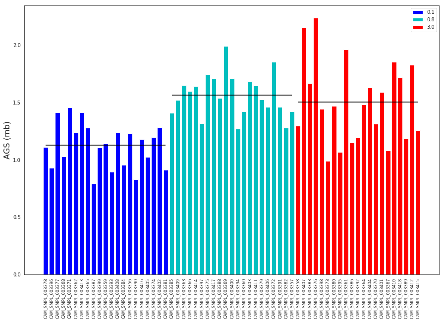

```python
sns.set_style("white")

plt.figure(figsize=(15,10))

#Here we are ploting on the same figure, 3 bar plots, ranging from the original index obtained from the merged dataframe

plt.bar(g1_.index,g1_["AGS (mb)"],color="b") # -> color b=blue, each bar plot we use different colors

plt.bar(g2_.index,g2_["AGS (mb)"],color="c")

plt.bar(g3_.index,g3_["AGS (mb)"],color="r")

plt.ylabel("AGS (mb)",size="16")
plt.xticks(range(len(merged)), merged["Sample"], size='small',rotation="vertical")
plt.legend(merged["FILTER_MIN"].drop_duplicates())

#here we plot 3 horizontal lines (hlines) with the mean of AGS values for each group
plt.hlines(g1_["AGS (mb)"].astype(float).mean(),g1_.index[0],g1_.index[-1])
plt.hlines(g2_["AGS (mb)"].astype(float).mean(),g2_.index[0],g2_.index[-1])
plt.hlines(g3_["AGS (mb)"].astype(float).mean(),g3_.index[0],g3_.index[-1])
plt.show()
```

### Starting with seaborn, using hue and crating more fancy plots

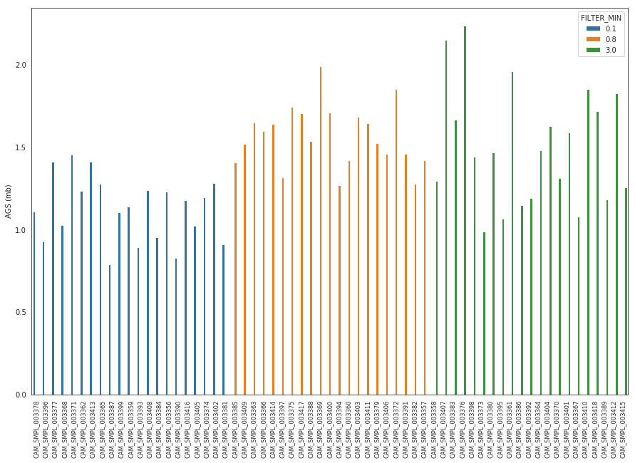

```python
sns.set_style("white")

plt.figure(figsize=(15,10))
x=merged.index
y="AGS (mb)"
sns.barplot(x=x,y=y,hue="FILTER_MIN",data=merged)
plt.xticks(range(len(x)), merged["Sample"], size='small',rotation="vertical")

plt.show()
```

# Hands-on:

- add the mean values line to the previous plot

### Barplot with error bars, violinplot and boxplots

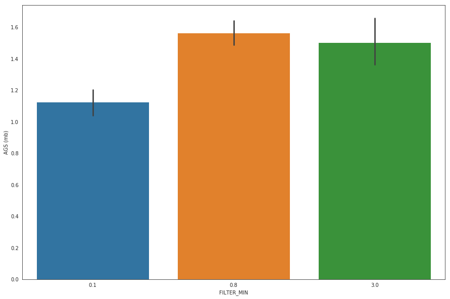

```python
sns.set_style("white")

plt.figure(figsize=(15,10))
x=merged["FILTER_MIN"]
y=merged["AGS (mb)"]
sns.barplot(x,y)
plt.show()
```

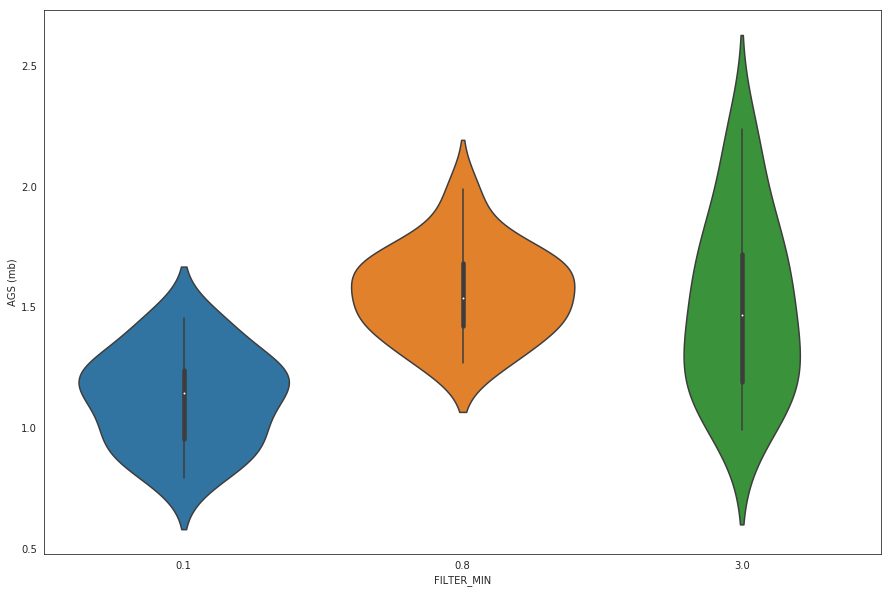

```python
sns.set_style("white")

plt.figure(figsize=(15,10))
x=merged["FILTER_MIN"]
y=merged["AGS (mb)"]
sns.violinplot(x,y)
plt.show()
```

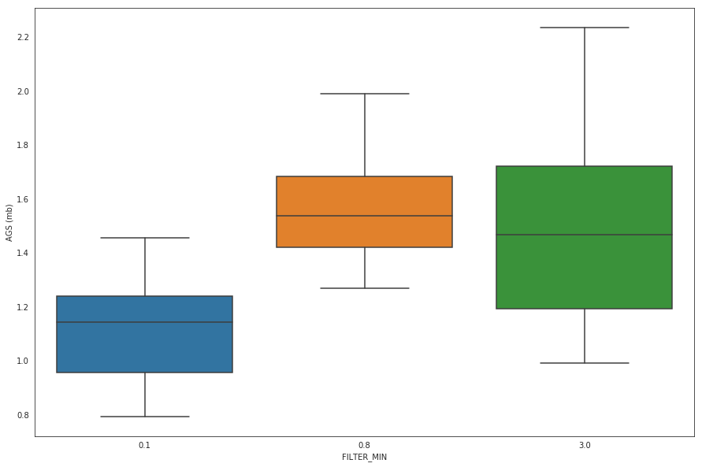

```python
sns.set_style("white")

plt.figure(figsize=(15,10))
x=merged["FILTER_MIN"]
y=merged["AGS (mb)"]
sns.boxplot(x,y)
plt.show()
```

# Hands on:

- create the same violin plots, but adding dots on the plot
- create violin plots for sample volume, instead filter min

## Exploring data, checking correlations

```python
#correlation between 2 variables

merged[["AGS (mb)","temperature - (C)"]].corr()
```

|  | AGS (mb) | temperature - (C) |
| --- | --- | --- |
| AGS (mb) | 1.000000 | 0.135368 |
| temperature - (C) | 0.135368 | 1.000000 |

## Do you think AGS (average genome size) are correlated with temperature?

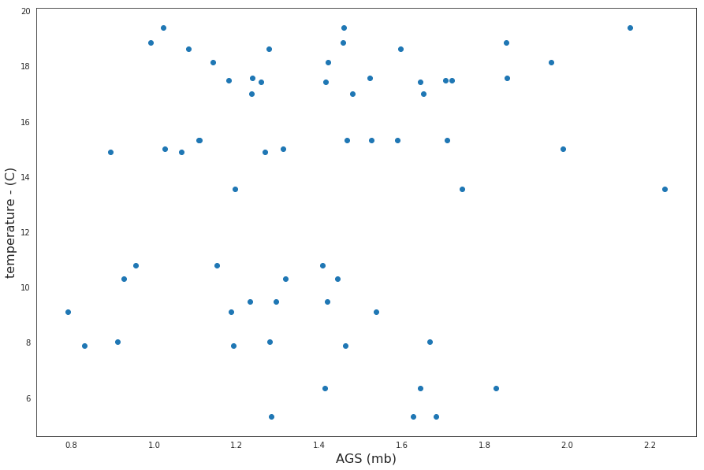

```python
#Doing a scatter plot

sns.set_style("white")
x=merged["AGS (mb)"]
y=merged["temperature - (C)"]
plt.figure(figsize=(15,10))
plt.scatter(x,y)
plt.ylabel("temperature - (C)",size="16")
plt.xlabel("AGS (mb)",size="16")
plt.show()
```

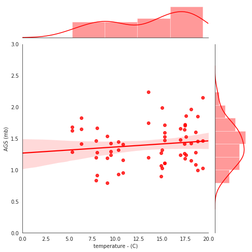

```python
sns.jointplot("temperature - (C)", "AGS (mb)", data=merged, kind="reg",
                  xlim=(0, 20), ylim=(0, 3), color="r", size=7)
plt.show()
```

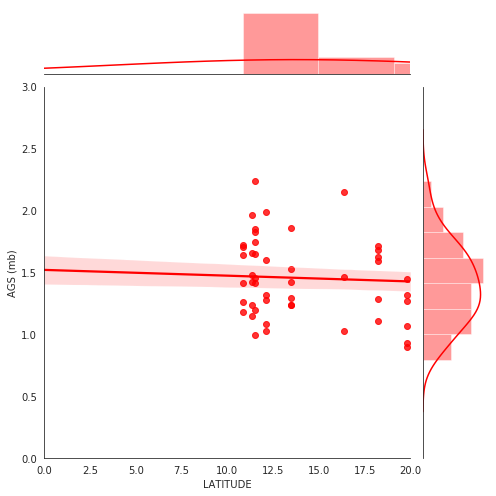

```python
sns.jointplot("LATITUDE", "AGS (mb)", data=merged, kind="reg",
                  xlim=(0, 20), ylim=(0, 3), color="r", size=7)
plt.show()
```